# Continuous Mixture Distributions

Allison C Fialkowski

2018-07-01

The following example demonstrates the use of the `contmixvar1` function, which simulates one continuous mixture distribution $Y$. Headrick (2002)’s fifth-order transformation is used to generate the components of $Y$ with `n = 10000`. Headrick and Kowalchuk (2007) outlined a general method for comparing a simulated distribution $Y$ to a given theoretical distribution $Y^*$. These have been modified below to apply to continuous mixture variables and will be shown for **Example 1**. Note that they could easily be modified further for comparison to an empirical vector of data. More details about continuous mixture variables can be found in the Expected Cumulants and Correlations for Continuous Mixture Variables vignette. Some code has been modified from the **SimMultiCorrData** package (Fialkowski 2018).

1. **Obtain the standardized cumulants** (skewness, kurtosis, fifth, and sixth) for the components of $Y^*$. This can be done using `SimMultiCorrData::calc_theory` along with either the component distribution names (plus up to 4 parameters for each) or the PDF’s with support bounds. In the case of an empirical vector of data, use `SimMultiCorrData::calc_moments` or `SimMultiCorrData::calc_fisherk` (Fialkowski 2018). If you desire $Y$ to have the mean and variance of $Y^*$, use `calc_mixmoments` with the component parameters as inputs to find $E[Y^*]$ and $SD[Y^*]$.
2. **Obtain the constants** for the components of $Y$. This can be done using `SimMultiCorrData::find_constants` on each component or by simulating the mixture variable with `contmixvar1`.
3. Determine whether these constants produce a **valid power method PDF**. The results of `find_constants` or `contmixvar1` indicate whether the constants yield invalid or valid PDF’s for the component variables. The constants may also be checked using `SimMultiCorrData::pdf_check`. If the constants generate an invalid PDF, the user should check if the skurtosis falls above the lower bound (using `SimMultiCorrData::calc_lower_skurt`). If yes, sixth cumulant correction values should be used in `SimMultiCorrData::find_constants` or `contmixvar1` to find the smallest corrections that produce valid PDF constants. If all of the component distributions have valid PDF’s, the mixture variable has a valid PDF.
4. **Select a critical value** from $Y^*$, i.e. $y^*$ such that $Pr(Y^* \ge y^*) = \alpha$ for the desired significance level $\alpha$.
5. **Calculate** the cumulative probability for the simulated mixture variable $Y$ up to $y^*$ and compare to $1 - \alpha$.
6. **Plot a parametric graph** of $Y^*$ and $Y$. This can be done with the simulated vector of data $Y$ using `plot_simpdf_theory` (`overlay` = TRUE) and specifying the PDF `fx` for the mixture variable. If comparing to an empirical vector of data, use `SimMultiCorrData::plot_sim_pdf_ext`.

# Example: Mixture of 2 Normal Distributions

The component distributions are *Normal(-2, 1)* and *Normal(2, 1)*. The mixing proportions are $0.4$ and $0.6$. Use Headrick and Kowalchuk (2007)’s steps to compare the density of the simulated variable to the theoretical density:

## Step 1: Obtain the standardized cumulants

The values of $\gamma_1,\ \gamma_2,\ \gamma_3,$ and $\gamma_4$ are all $0$ for normal variables. The mean and standard deviation of the mixture variable are found with `calc_mixmoments`.

```r
library("SimCorrMix")
library("printr")
options(scipen = 999)
n <- 10000
mix_pis <- c(0.4, 0.6)
mix_mus <- c(-2, 2)
mix_sigmas <- c(1, 1)
mix_skews <- rep(0, 2)
mix_skurts <- rep(0, 2)
mix_fifths <- rep(0, 2)
mix_sixths <- rep(0, 2)
Nstcum <- calc_mixmoments(mix_pis, mix_mus, mix_sigmas, mix_skews,
  mix_skurts, mix_fifths, mix_sixths)
```

## Step 2: Simulate the variable

Note that `calc_mixmoments` returns the standard deviation, not the variance. The simulation functions require variance as the input. First, the parameter inputs are checked with `validpar`.

```r
validpar(k_mix = 1, method = "Polynomial", means = Nstcum[1],
  vars = Nstcum[2]^2, mix_pis = mix_pis, mix_mus = mix_mus,
  mix_sigmas = mix_sigmas, mix_skews = mix_skews, mix_skurts = mix_skurts,
  mix_fifths = mix_fifths, mix_sixths = mix_sixths)
```

```
## [1] TRUE
```

```r
Nmix2 <- contmixvar1(n, "Polynomial", Nstcum[1], Nstcum[2]^2, mix_pis, mix_mus,
  mix_sigmas, mix_skews, mix_skurts, mix_fifths, mix_sixths)
```

```
## Total Simulation time: 0.001 minutes
```

Look at a summary of the target distribution and compare to a summary of the simulated distribution.

```r
SumN <- summary_var(Y_comp = Nmix2$Y_comp, Y_mix = Nmix2$Y_mix,
  means = Nstcum[1], vars = Nstcum[2]^2, mix_pis = mix_pis, mix_mus = mix_mus,
  mix_sigmas = mix_sigmas, mix_skews = mix_skews, mix_skurts = mix_skurts,
  mix_fifths = mix_fifths, mix_sixths = mix_sixths)
knitr::kable(SumN$target_mix, digits = 5, row.names = FALSE,
  caption = "Summary of Target Distribution")
```

Table 1: Summary of Target Distribution

| Distribution | Mean | SD | Skew | Skurtosis | Fifth | Sixth |
| --- | --- | --- | --- | --- | --- | --- |
| 1 | 0.4 | 2.2 | -0.2885 | -1.15402 | 1.79302 | 6.17327 |

```r
knitr::kable(SumN$mix_sum, digits = 5, row.names = FALSE,
  caption = "Summary of Simulated Distribution")
```

Table 1: Summary of Simulated Distribution

| Distribution | N | Mean | SD | Median | Min | Max | Skew | Skurtosis | Fifth | Sixth |
| --- | --- | --- | --- | --- | --- | --- | --- | --- | --- | --- |
| 1 | 10000 | 0.4 | 2.19989 | 1.05078 | -5.69433 | 5.341 | -0.2996 | -1.15847 | 1.84723 | 6.1398 |

## Step 3: Determine if the constants generate a valid PDF

```r
Nmix2$constants
```

| c0 | c1 | c2 | c3 | c4 | c5 |
| --- | --- | --- | --- | --- | --- |
| 0 | 1 | 0 | 0 | 0 | 0 |
| 0 | 1 | 0 | 0 | 0 | 0 |

```r
Nmix2$valid.pdf
```

```
## [1] "TRUE" "TRUE"
```

## Step 4: Select a critical value

Let $\alpha = 0.05$. Since there are no quantile functions for mixture distributions, determine where the cumulative probability equals $1 - \alpha = 0.95$. The boundaries for `uniroot` were determined through trial and error.

```r
fx <- function(x) 0.4 * dnorm(x, -2, 1) + 0.6 * dnorm(x, 2, 1)
cfx <- function(x, alpha, FUN = fx) {
  integrate(function(x, FUN = fx) FUN(x), -Inf, x, subdivisions = 1000,
    stop.on.error = FALSE)$value - (1 - alpha)
}
y_star <- uniroot(cfx, c(3.3, 3.4), tol = 0.001, alpha = 0.05)$root
y_star
```

```
## [1] 3.382993
```

## Step 5: Calculate the cumulative probability for the simulated variable up to $1 - \alpha$

We will use the function `SimMultiCorrData::sim_cdf_prob` to determine the cumulative probability for $Y$ up to `y_star`. This function is based on Martin Maechler’s `ecdf` function (R Core Team 2018).

```r
sim_cdf_prob(sim_y = Nmix2$Y_mix[, 1], delta = y_star)$cumulative_prob
```

```
## [1] 0.9504
```

This is approximately equal to the $1 - \alpha$ value of $0.95$, indicating the method provides a **good approximation to the actual distribution.**

## Step 6: Plot graphs

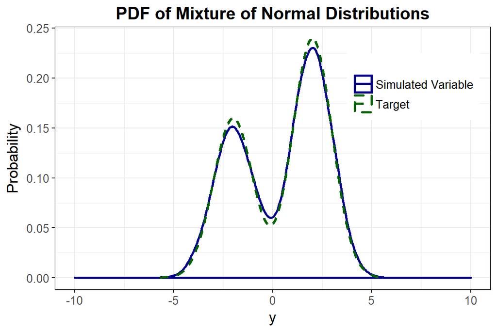

```r
plot_simpdf_theory(sim_y = Nmix2$Y_mix[, 1], ylower = -10, yupper = 10,
  title = "PDF of Mixture of Normal Distributions", fx = fx, lower = -Inf,
  upper = Inf)
```

We can also plot the empirical cdf and show the cumulative probability up to y_star.

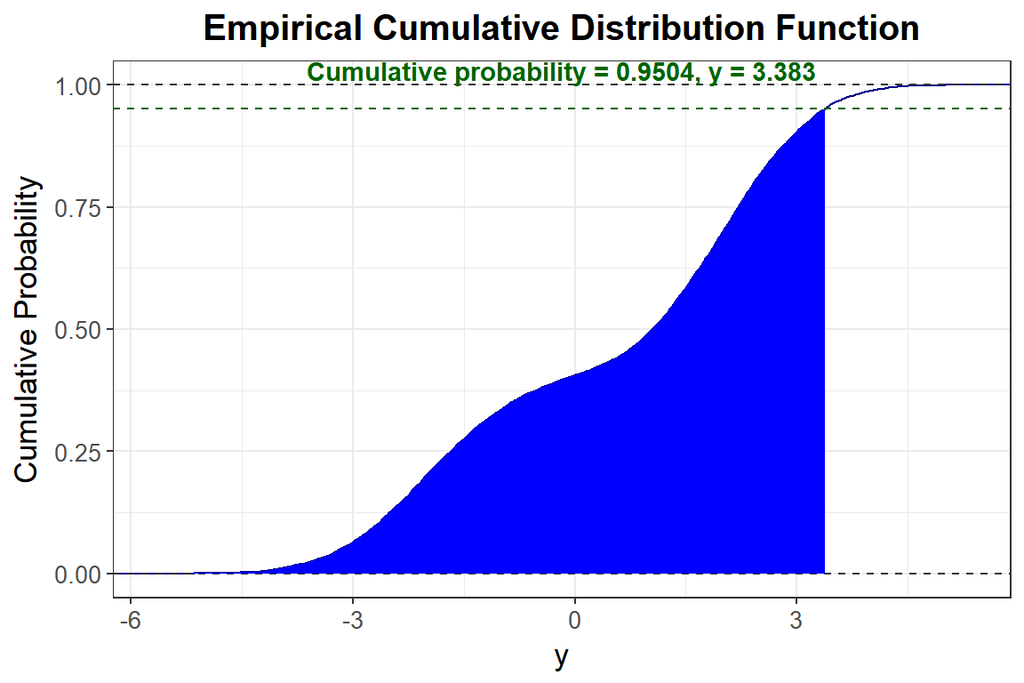

```r
plot_sim_cdf(sim_y = Nmix2$Y_mix[, 1], calc_cprob = TRUE, delta = y_star)
```

# References

Fialkowski, A C. 2018. *SimMultiCorrData: Simulation of Correlated Data with Multiple Variable Types*. https://CRAN.R-project.org/package=SimMultiCorrData.

Headrick, T C. 2002. “Fast Fifth-Order Polynomial Transforms for Generating Univariate and Multivariate Non-Normal Distributions.” *Computational Statistics and Data Analysis* 40 (4): 685–711. https://doi.org/10.1016/S0167-9473(02)00072-5.

Headrick, T C, and R K Kowalchuk. 2007. “The Power Method Transformation: Its Probability Density Function, Distribution Function, and Its Further Use for Fitting Data.” *Journal of Statistical Computation and Simulation* 77: 229–49. https://doi.org/10.1080/10629360600605065.

R Core Team. 2018. *R: A Language and Environment for Statistical Computing*. Vienna, Austria: R Foundation for Statistical Computing. https://www.R-project.org/.